# Nature Use Survey Analysis

Q5.6 is about what typicaly do on campus, I don’t know how to do the test now, may do it in the future.

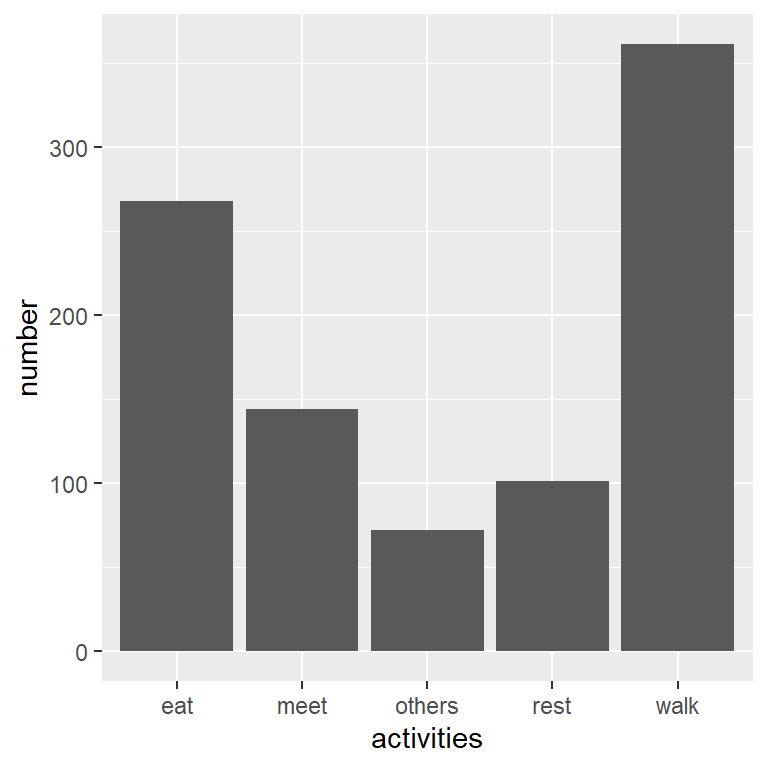

```r
Q5.6 %>%
  pivot_longer(eat:others,
               names_to = "activities",
               values_to = "number") %>%
  group_by(activities) %>%
  summarise_all(sum) %>%
  ggplot(mapping = aes(x=activities,y=number)) +
  geom_bar(stat="identity")
```

```r
Q5.6.sum<-Q5.6 %>%
  pivot_longer(eat:others,
               names_to = "activities",
               values_to = "number") %>%
  group_by(activities) %>%
  summarise_all(sum)

Q5.6.sum[,c(1,3)]
```

```
## # A tibble: 5 x 2
##   activities number
##   <chr>       <dbl>
## 1 eat           268
## 2 meet          144
## 3 others         72
## 4 rest          101
## 5 walk          361
```

Q 3.2 is asking what activities typically do before and during covid?

Total number of types of activities is signifianctly decreasing but the amount is not large (0.2). Restorative activities are increasing while social activities are decreasing during the COVID.

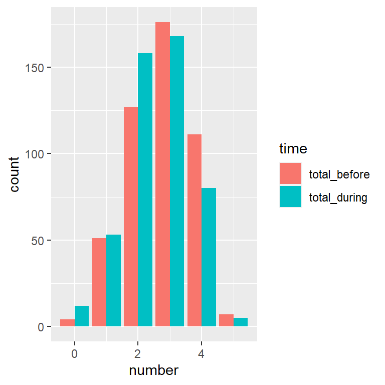

```r
Q3.2 %>%
  pivot_longer(total_before:total_during,
               names_to = "time",
               values_to = "number") %>%
  ggplot(mapping = aes(x=number,fill=time)) +
  geom_bar(stat="count",position='dodge')
```

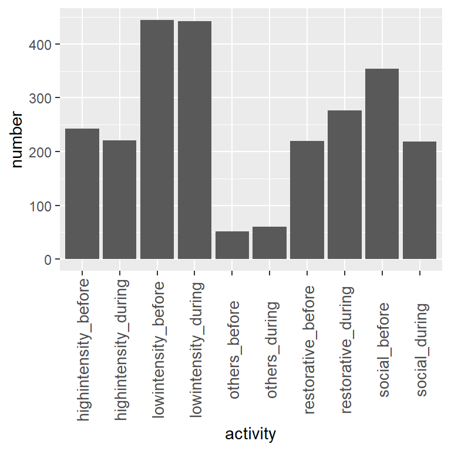

```r
Q3.2 %>%
  pivot_longer(social_before:others_during,
               names_to = "activity",
               values_to = "number") %>%
  group_by(activity) %>%
  summarise_all(sum) %>%
  ggplot(mapping = aes(x=activity,y=number)) +
  geom_bar(stat="identity")+
  theme(axis.text.x = element_text(size=10,angle = 90,hjust=.5,vjust=.5,face="plain"))
```

```r
res3 <- t.test(Q3.2$total_before, Q3.2$total_during, paired = TRUE)
res3
```

```
##
##  Paired t-test
##
## data:  Q3.2$total_before and Q3.2$total_during
## t = 3.7913, df = 475, p-value = 0.0001692
## alternative hypothesis: true difference in means is not equal to 0
## 95 percent confidence interval:
##  0.0951283 0.2998297
## sample estimates:
## mean of the differences
##                0.197479
```

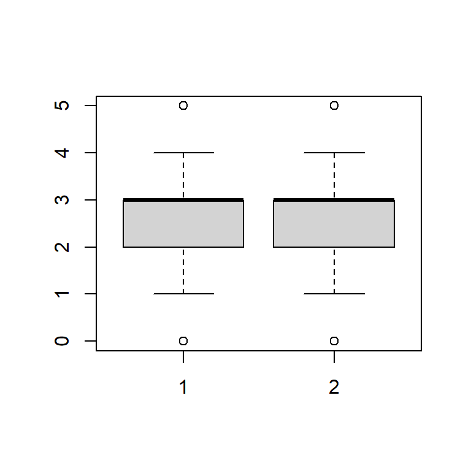

```r
boxplot(Q3.2$total_before, Q3.2$total_during)
```

```r
mean(Q3.2$total_before)- mean(Q3.2$total_during)
```

```
## [1] 0.197479
```

c. Why do they spend time outdoors in nature, and how did this change during covid (Q4.2)  
c1. Correlation between WHY and time outdoors  
c2. How do reasons for spending time outdoors intersect with:  
i. Who they spent time with ii. barriers

The total number of reasons for spending time outdoors is not change. The c1 and c2 questions are difficult for me and I need help from Statistics.

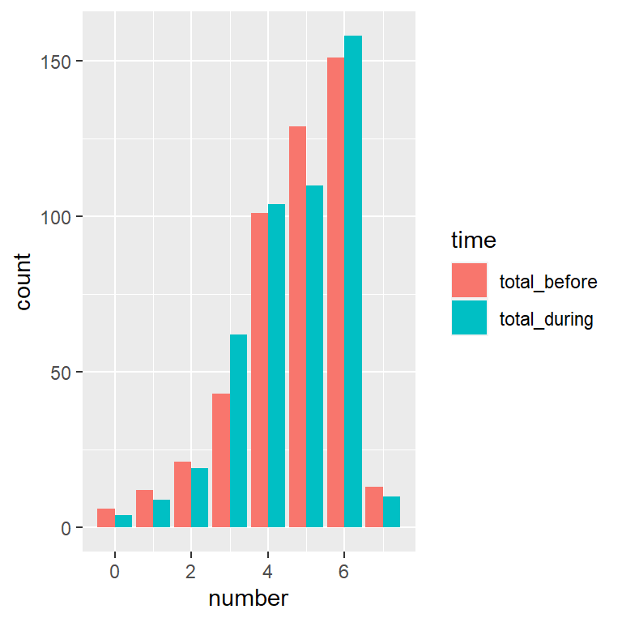

```r
Q4.2 %>%
  pivot_longer(total_before:total_during,
               names_to = "time",
               values_to = "number") %>%
  ggplot(mapping = aes(x=number,fill=time)) +
  geom_bar(stat="count",position='dodge')
```

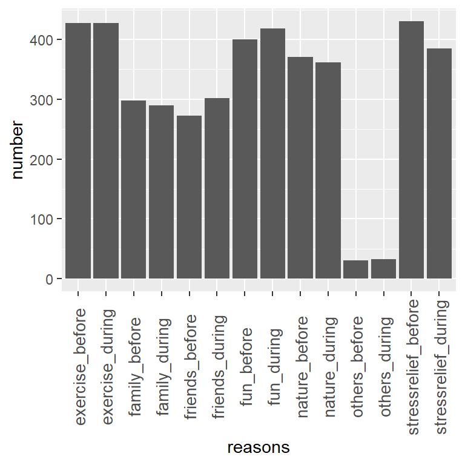

```r
Q4.2.sum<-Q4.2 %>%
  pivot_longer(exercise_before:others_during,
               names_to = "reasons",
               values_to = "number") %>%
  group_by(reasons) %>%
  summarise_all(sum)

Q4.2.sum%>%
  ggplot(mapping = aes(x=reasons,y=number)) +
  geom_bar(stat="identity")+
  theme(axis.text.x = element_text(size=10,angle = 90,hjust=.5,vjust=.5,face="plain"))
```

```r
Q4.2.sum[,c(1,4)]
```

```
## # A tibble: 14 x 2
##    reasons             number
##    <chr>                <dbl>
##  1 exercise_before        427
##  2 exercise_during        427
##  3 family_before          298
##  4 family_during          290
##  5 friends_before         272
##  6 friends_during         302
##  7 fun_before             400
##  8 fun_during             418
##  9 nature_before          371
## 10 nature_during          362
## 11 others_before           31
## 12 others_during           33
## 13 stressrelief_before    430
## 14 stressrelief_during    385
```

```r
res4 <- t.test(Q4.2$total_before, Q4.2$total_during, paired = TRUE)
res4
```

```
##
##  Paired t-test
##
## data:  Q4.2$total_before and Q4.2$total_during
## t = 0.37141, df = 475, p-value = 0.7105
## alternative hypothesis: true difference in means is not equal to 0
## 95 percent confidence interval:
##  -0.1081656  0.1585858
## sample estimates:
## mean of the differences
##              0.02521008
```

d. Is there a connection between people’s motivation for spending time in nature (Q4.2) attitudes towards nature (Q4.4) OR perceived benefits (Q4.3) and time spent outdoors [both per and post covid] (Q2.5 to 2.10) – does this differ for any demographic groups

Hope to get answers for this complex questions from Statistics Consulting.

e. By neighborhood type are there changes in the number and type of places used pre to post covid, and within and across subjects

The total number of change is not correlated with neighborhood.

```r
usechange<-Q2.4.score$use.score.after-Q2.4.score$use.score.before
Q5.e<-xtabs(~df.chi$neighbortype+usechange)
Q5.e
```

```
##                    usechange
## df.chi$neighbortype -8 -7 -6 -5 -4 -3 -2 -1  0  1  2  3  4  5  6  8
##             Rurl     2  1  0  1  2  2  9 16 64 13  6  1  2  0  0  0
##             Smlltwn  0  1  2  1  4  7 11 14 52 10  3  5  2  3  1  1
##             Sbrb     0  0  0  1  1  1  2 14 31  4  4  2  2  1  0  0
##             Smllcty  0  1  1  2  2  5  4 16 65 12  8  5  4  1  3  0
##             Lrgcty   0  0  0  0  1  0  2  2  5  0  1  0  0  0  0  0
```

```r
CMHtest(Q5.e)
```

```
## Cochran-Mantel-Haenszel Statistics for df.chi$neighbortype by usechange
##
##                  AltHypothesis   Chisq Df    Prob
## cor        Nonzero correlation  2.2191  1 0.13631
## rmeans  Row mean scores differ  4.7871  4 0.30985
## cmeans  Col mean scores differ 10.4033 15 0.79363
## general    General association 49.8629 60 0.82161
```

f. Is there increased contact with nature as a result of covid? A difficult question.  
g. More using outdoors early in the pandemic versus Fall 2020, and Fall 2020 went somewhat back to Fall 2019 levels g1. What does this intersect with – attitudes?

NOT done yet.